# Circular Permutations

Teun van den Brand

Netherlands Cancer Institute  
t.vd.brand@nki.nl

2020-10-09

## Setup

### Load packages

```r
library(rtracklayer)
library(GenomicRanges)
library(regioneR)
library(abind)
library(BiocParallel)
library(Biostrings)

library(magrittr)
library(gt)
library(ggplot2)
```

### Data

#### Files

```r
project_dir <- "/DATA/projects/ES_Wapl_AID/"
get_file <- function(file) paste0(project_dir, file)

# BED file with loss and gain regions of Rad21
gain_loss_file <- paste0(
  project_dir,
  "ChIPseq/Normalized_SIChIP/gainloss_201906/rad21_loss_gain_merged_2019-06.bed"
)

# BED File with transcription start sites
tss_file <- paste0(
  project_dir,
  "ChIPseq/WCR_ChIP/Rad21_loss_gain/mm10_tss/Ensembl_id_annotation_mm10_all_geneTSS_2019-03-19.bed"
)

# Files with differential expression results (DEseq2)
DE_files <- setNames(paste0(
  project_dir, "WAPL_revision/",
  c(
    "Permutation_WAPL-C6/Wapl_all_fdr0.05_2020-08-13.txt",
    "RNA/WAPLC20/analysis/WAPL-C20_significant_genes_2020-05-29.txt",
    "Permutation_WAPL-C6/Rad21_all_fdr0.05_2020-08-13.txt",
    "TTchem_finalized/analysis/WAPL-TTchem_significant_genes_WAPLC6_only_2020-07-14.txt"
  )
), c("WAPL_C6", "WAPL_C20", "RAD21_AID", "TTCHEM"))
```

#### Loading

```r
regions <- import.bed(gain_loss_file)
tss <- read.delim(tss_file, header = FALSE,
                  stringsAsFactors = FALSE)
rna_results <- lapply(DE_files, read.table,
                      header = TRUE, stringsAsFactors = FALSE)
```

### Setup Aesthetics

```r
mycolour <- "#000000FF" # Opaque Black

theme_set(theme_gray())
theme_update(text = element_text(colour = mycolour),
             line = element_line(colour = mycolour),
             aspect.ratio = 1,
             axis.line  = element_line(colour = mycolour),
             axis.ticks = element_line(colour = mycolour),
             axis.text  = element_text(colour = mycolour),
             legend.key = element_blank(),
             panel.background = element_blank(),
             panel.grid.major = element_line(colour = "grey95"),
             panel.grid.major.x = element_blank(),
             panel.spacing.y = unit(10, "pt"),
             panel.grid.minor = element_blank(),
             plot.background  = element_blank(),
             strip.background = element_blank(),
             strip.text = element_text(colour = mycolour))

rm(mycolour)
```

### Functions

```r
tally_nearest <- function(regions, genes) {
  # Find nearest genes
  near <- nearest(regions, genes, select = "all")

  # Exclude genes that are nearest for both a gain and a loss regions
  type <- regions$name[from(near)]
  type <- split(to(near), type)
  delete <- intersect(type$gain, type$loss)
  near <- near[!(to(near) %in% delete)]

  # Only count a gene once, even if nearest for two regions
  near <- near[!duplicated(to(near))]

  # Decode hits to features
  nearby_genes <- mcols(genes[to(near)])
  target <- regions$name[from(near)]

  # Tally per category
  counts <- lapply(nearby_genes, function(i){
    as.matrix(table(target, direction = i))
  })

  # Format as array
  counts <- do.call(abind, list(counts, along = 3))
}
```

## Aim

Permute called Rad21 gain/loss domains and intersect with up/down regulated genes to see if there is an enrichment in some conditions.

## Data wrangling

Getting all the data in the right format; that is the location of the TSS annotated with the direction of the gene in every dataset/timepoint sampleset.

### Genes

We keep the TSSs from protein coding genes that were tested for differential expression.

```r
# Convert protein coding TSSs to GRanges
tss <- tss[tss$V7 == "protein_coding",]
tss <- with(tss, setNames(GRanges(V1, IRanges(V2 + 1, V3)), V5))

# Convert genespaces to TSS locations
genespaces <- lapply(lapply(rna_results,  `[[`, "ensembl_gene_id"), unique)
genespaces <- lapply(genespaces, function(i) {
  tss[intersect(i, names(tss))]
})

all_genes <- Reduce(union, lapply(genespaces, names))
tss <- tss[all_genes]
```

### DE Results

```r
# Subset by genes we approved above
rna_results <- mapply(function(res, space) {
  res[res$ensembl_gene_id %in% names(space), ]
}, res = rna_results, space = genespaces, SIMPLIFY = FALSE)

# Combine RNA results
rna <- data.table::rbindlist(rna_results, idcol = "dataset")
data.table::setDF(rna)

# Split RNA results by dataset/time
rna <- split(rna, interaction(rna$dataset, rna$time, drop = TRUE))
dataset <- data.table::tstrsplit(names(rna), "\\.")[[1]]

# Annotate gene change direction
rna <- mapply(function(set, space) {
  # note: log fold changes are in reverse for some reason
  up <- subset(set, log2FoldChange < 0 & !is.na(padj) & padj < 0.05,
               ensembl_gene_id)[[1]]
  down <- subset(set, log2FoldChange > 0 & !is.na(padj) & padj < 0.05,
                 ensembl_gene_id)[[1]]

  factor(ifelse(
    all_genes %in% up, "up",
    ifelse(all_genes %in% down, "down",
           # Use 'void' factor for genes not in the genespace at all
           ifelse(all_genes %in% names(space), "neutral", "void")
           )
  ), levels = c("up", "down", "neutral", "void"))
}, set = rna, space = genespaces[dataset], SIMPLIFY = FALSE)

# Append as metadata to TSSs
rna <- do.call(cbind.data.frame, rna)
mcols(tss) <- as(rna, "DataFrame")

# For efficiency, convert TSS to nested containment list
tss <- as(tss, "GNCList")
```

## Circular permutations

We circularly permute the Rad21 gain and loss regions with the `regionR` package.

```r
# Setup permutations
n <- 10000
set.seed(0)
seeds <- sample(10e6, n)
genome <- getGenomeAndMask("mm10", mask = NA)$genome
cores <- MulticoreParam(workers = 10)

# Circularly permute
random_regions <- bplapply(seeds, function(seed) {
  set.seed(seed)
  circularRandomizeRegions(
    regions,
    genome = genome, make = NA, per.chromosome = FALSE
  )
}, BPPARAM = cores)
```

## Calculating overlaps

For every RNA set of DE genes, we calculate the number of genes that are nearby Rad21 loss or gain regions.

### Real data

```r
# The `tally_nearest()` function is defined in the setup of this document.
counts <- tally_nearest(regions, tss)

# Drop 'void' class
not_void <- which(dimnames(counts)[[2]] != "void")
counts <- counts[, not_void, ]
```

### Permuted data

```r
# Use tally_nearest for every permutation seperately
perm <- bplapply(
  random_regions, tally_nearest,
  genes = tss, BPPARAM = cores
)
perm <- do.call(abind, list(perm, along = 4))

# Drop 'void' class
not_void <- which(dimnames(perm)[[2]] != "void")
perm <- perm[, not_void, , ]

# Add permutation number as name
dimnames(perm)[[4]] <- seq_len(n)
```

## Calculating statistics

### Observed over expected

The ‘observed’ part is the number of nearest genes whereas the expected part is the sum of observed genes times the background frequency of genes across the whole dataset.

```r
# Calculate background frequency of up/down/neutral genes per dataset/timepoint
bg_freqs <- lapply(mcols(tss), function(i) {
  # Drop void class (the 4th factor level)
  tab <- table(direction = i)[-4]
  tab / sum(tab)
})

obsexp_real <- lapply(setNames(nm = names(bg_freqs)), function(i) {
  obs <- counts[, , i]
  exp <- t(t(rowSums(obs))) %*% bg_freqs[[i]]
  # Guard against dividing by 0
  obs / pmax(exp, 1e-8)
})
obsexp_real <- do.call(abind, list(obsexp_real, along = 3))

obsexp_perm <- vapply(seq_len(n), function(j) {
  permed <- perm[, , , j]
  obsexp <- lapply(setNames(nm = names(bg_freqs)), function(i) {
    obs <- permed[, , i]
    exp <- t(t(rowSums(obs))) %*% bg_freqs[[i]]
    # Guard against dividing by 0
    obs / pmax(exp, 1e-8)
  })
  do.call(abind, list(obsexp, along = 3))
}, obsexp_real)
```

### Count extremes and quantiles

To estimate P-values empirically we need to count the number that a permuted observed over expected value exceeds the observed over expected value of the true dataset.

```r
# Take all combinations of Rad21 regions, gene direction and datasets
idx <- expand.grid(dimnames(obsexp_real))

# Count values in permuted larger than real
greater <- apply(idx, 1, function(i) {
  real_val <- obsexp_real[i[[1]], i[[2]], i[[3]]]
  perm_val <- obsexp_perm[i[[1]], i[[2]], i[[3]], ]
  sum(perm_val > real_val)
})

# Count values in permuted smaller than real
smaller <- apply(idx, 1, function(i) {
  real_val <- obsexp_real[i[[1]], i[[2]], i[[3]]]
  perm_val <- obsexp_perm[i[[1]], i[[2]], i[[3]], ]
  sum(perm_val < real_val)
})

# Calculate P values
p_val <- vapply(greater, function(ngreater) {
  statmod::permp(ngreater, n, total.nperm = sum(seqlengths(genome)))
}, numeric(1))
fdr_val <- p.adjust(p_val, method = "fdr")

# Calculate quantiles
# 95% confidence interval and quartiles
quantiles <- c(0.025, 0.25, 0.5, 0.75, 0.975)
quantiles <- apply(obsexp_perm, 1:3, quantile, quantiles)
quantiles <- reshape2::melt(quantiles)
quantiles <- tidyr::pivot_wider(quantiles,
                                names_from = Var1, values_from = value)
```

## Summary table

```r
summary <- reshape2::melt(obsexp_real)
sample <- data.table::tstrsplit(summary$Var3, "\\.")

# Check if the ordering is OK
assumptions <- c(
  all(idx$Var1 == summary$Var1),
  all(idx$Var2 == summary$Var2),
  all(idx$Var3 == summary$Var3),
  all(idx$Var1 == quantiles$Var2),
  all(idx$Var2 == quantiles$Var3),
  all(idx$Var3 == quantiles$Var4)
)
if (!all(assumptions)) {
  print("Not all ordering assumptions have been met!")
}

# Gather all summary data
summary <- data.frame(
  Rad21 = factor(as.character(summary$Var1),
                 levels = c("gain", "loss")),
  Direction = factor(as.character(summary$Var2),
                     levels = c("down", "neutral", "up")),
  Dataset = factor(sample[[1]],
                   c("WAPL_C6", "WAPL_C20", "RAD21_AID", "TTCHEM")),
  Timepoint = factor(sample[[2]],
                     levels = c("6h", "24h", "48h", "96h"), ordered = TRUE),
  ObsExp = summary$value,
  Smaller = smaller,
  Greater = greater,
  quantiles[, -c(1:3)],
  Pval = p_val,
  FDRval = fdr_val,
  check.names = FALSE
)

# Print pretty table
gt(summary) %>%
  tab_spanner("Permutation percentiles", colnames(quantiles)[-c(1:3)]) %>%
  tab_spanner("Condition", vars(Rad21, Direction, Dataset, Timepoint)) %>%
  tab_spanner("# Permutations", vars(Smaller, Greater)) %>%
  fmt_number(c("ObsExp", colnames(quantiles)[-c(1:3)])) %>%
  fmt(vars(Pval, FDRval), fns = scales::pvalue) %>%
  tab_style(
    cell_text(color = "red", weight = "bold"),
    locations = cells_body(vars(FDRval), rows = FDRval < 0.05)
  )
```

[output not shown]

## Visualise

### Data formatting

```r
realdat <- summary
realdat$labels <- ""
realdat$labels[realdat$FDRval < 0.01] <- "*"
realdat$labels[realdat$FDRval < 0.001] <- "**"
realdat$labels[realdat$FDRval < 0.0001] <- "***"

permdat <- reshape2::melt(obsexp_perm)
sample  <- data.table::tstrsplit(permdat$Var3, "\\.")
permdat <- permdat[, -c(3, 4)]
names(permdat) <- c("Rad21", "Direction", "ObsExp")
permdat <- transform(
  permdat,
  Dataset = factor(sample[[1]],
                   levels = levels(realdat$Dataset)),
  Timepoint = factor(sample[[2]],
                     levels = levels(realdat$Timepoint)),
  Rad21 = factor(as.character(Rad21),
                 levels = levels(realdat$Rad21)),
  Direction = factor(as.character(Direction),
                     levels = levels(realdat$Direction))
)

realdat <- split(realdat, realdat$Dataset)
permdat <- split(permdat, permdat$Dataset)
```

### Plotting

```r
plots <- mapply(function(df_real, df_perm) {
  ggplot(df_real, aes(Timepoint, ObsExp)) +
    geom_violin(
      data = df_perm,
      aes(colour = Rad21, fill = after_scale(colorspace::lighten(colour, 0.3))),
      adjust = 4, draw_quantiles = c(0.25, 0.5, 0.75), scale = "width"
    ) +
    geom_point(shape = "\u2605", size = 5) +
    geom_text(aes(label = labels), nudge_y = 1) +
    scale_y_continuous(
      name = expression(frac("Observed", "Expected")),
      expand = c(0,0),
      breaks = scales::breaks_extended(Q = c(1, 2, 5)),
      limits = function(x) {c(0, x[2] + 1)}
    ) +
    scale_x_discrete(name = "") +
    scale_colour_brewer(name = "Rad21 Domain", palette = "Set1") +
    facet_grid(Rad21 ~ Direction) +
    theme(aspect.ratio = (1 + sqrt(5))/2) +
    ggtitle(df_real$Dataset[[1]])
}, df_real = realdat, df_perm = permdat, SIMPLIFY = FALSE)

for (i in names(plots)) {
  cat(paste0("\n\n#### ", i, "\n"))
  print(plots[[i]])
}
```

#### WAPL_C6

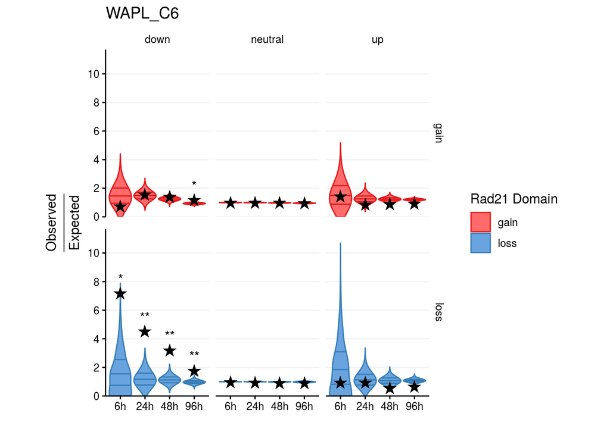

#### WAPL_C20

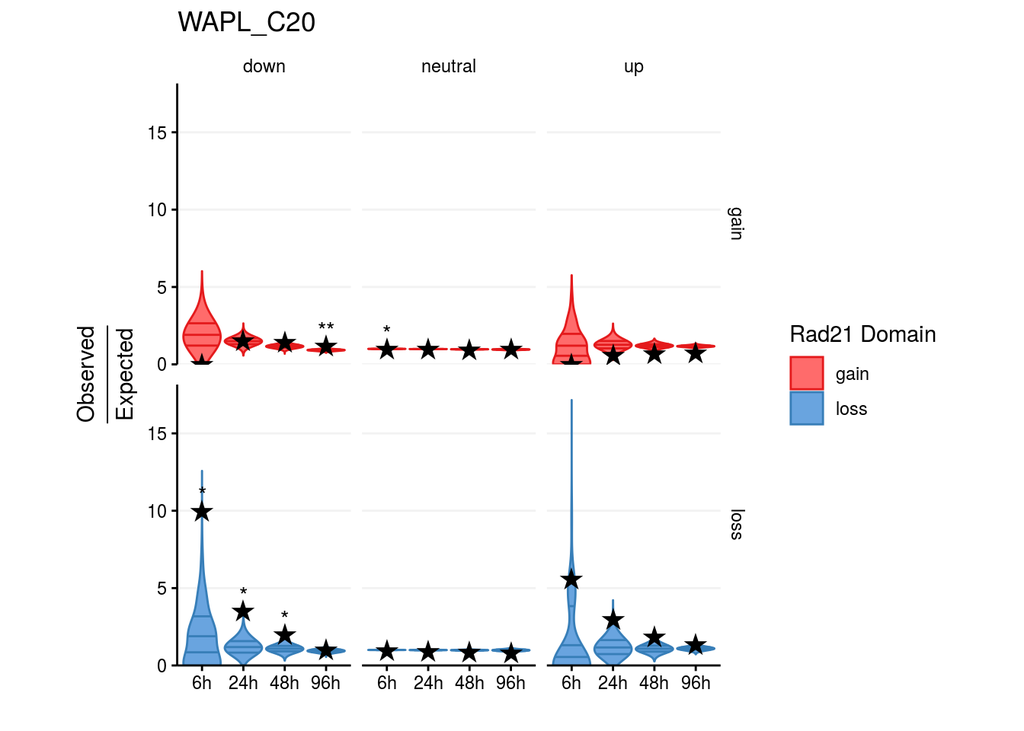

#### RAD21_AID

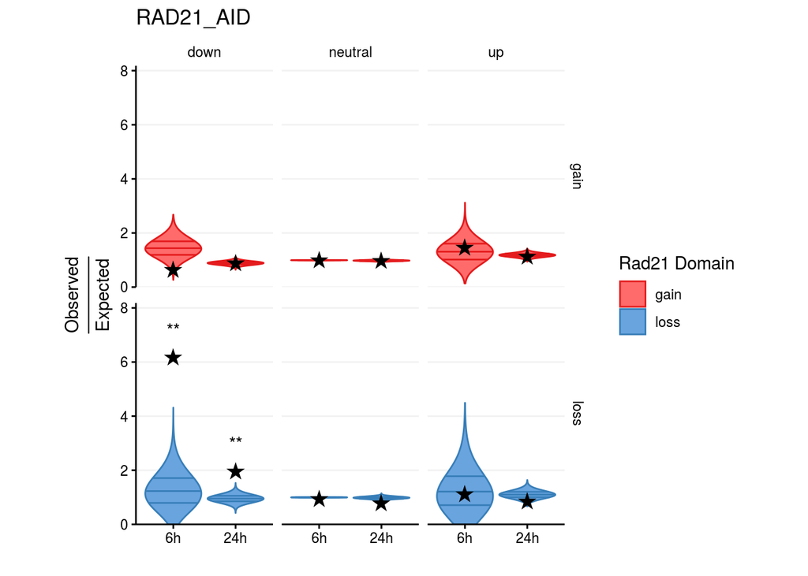

#### TTCHEM

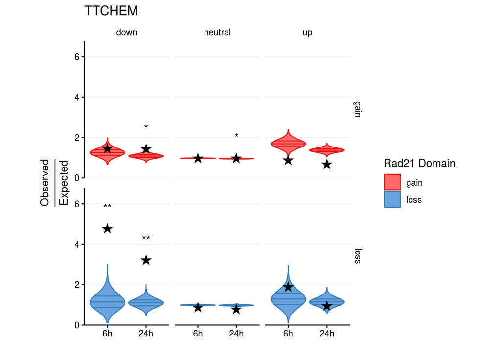